# GSEA Ribo vs polyA

Ariel Hippen

2022-07-28

# Analyzing differential expression results

We have calculated differential expression genes in DE_ribo_vs_polyA.Rmd, now we will try to make sense of them. Our main workhorse will be Gene Set Enrichment Analysis (GSEA) across several reference sets.

```r
suppressPackageStartupMessages({
  library(DESeq2)
  library(WebGestaltR)
  library(ggplot2)
  library(rtracklayer)
})

source("../../config.R")
```

```r
# Load the DESeq2 object with the original count matrix
deseq_path <- paste(local_data_path, "deseq2_output", sep = "/")
dds <- readRDS(paste(deseq_path, "ribo_vs_polyA_data.rds", sep = "/"))

# Load the DESeqResults object with differentially expressed genes, at FDR 0.1 and 0.05
res1 <- readRDS(paste(deseq_path, "ribo_vs_polyA_FDR_0.1.rds", sep = "/"))
res05 <- readRDS(paste(deseq_path, "ribo_vs_polyA_FDR_0.05.rds", sep = "/"))
```

## Top genes

Let’s look at the top 20 most upregulated and downregulated genes and see if we can find a pattern.

```r
res1 <- subset(res1, res1$padj < 0.1)
res1 <- res1[order(res1$log2FoldChange), ]
as.data.frame(head(res1, n=20))
```

```
##                baseMean log2FoldChange     lfcSE       stat        pvalue
## RMRP       24000.731646     -11.350487 0.5204542 -21.808808 1.913968e-105
## AL356488.2  6402.189419     -11.192611 0.4557820 -24.556941 3.646291e-133
## AL355075.4 10035.558064     -10.486047 0.3934179 -26.653710 1.620973e-156
## AL627171.2 32028.174113      -8.953906 0.3508589 -25.519965 1.183609e-143
## AC006064.5   800.339233      -8.676798 0.4171055 -20.802409  4.116075e-96
## HIST1H4F     126.165209      -7.584147 0.6718555 -11.288360  1.498057e-29
## TERC         380.580052      -7.565524 0.4326045 -17.488317  1.758762e-68
## HIST1H1E    3875.456278      -7.466552 0.3881176 -19.237858  1.784320e-82
## HIST1H3I      97.949551      -7.450876 0.4741335 -15.714724  1.199025e-55
## HIST1H4L      28.497041      -7.407631 0.7322943 -10.115648  4.708914e-24
## HIST1H4B     195.566155      -7.098757 0.5481861 -12.949537  2.363749e-38
## HIST1H4A     130.716736      -6.862988 0.7576443  -9.058325  1.324685e-19
## HIST1H3F     259.470135      -6.856573 0.4361862 -15.719372  1.114223e-55
## HIST1H1B     658.088415      -6.657982 0.4850095 -13.727530  6.946162e-43
## AC009686.1     9.232829      -6.360311 0.8327379  -7.637830  2.209135e-14
## HIST1H2BI    183.101743      -6.321904 0.5317333 -11.889239  1.346270e-32
## PRKCA-AS1     36.574623      -6.316965 0.7225019  -8.743181  2.266365e-18
## AC023385.1    18.779022      -6.209457 0.6563505  -9.460581  3.062363e-21
## AC051619.7    10.648389      -6.177520 0.8078444  -7.646918  2.058532e-14
## HIST1H4C     319.913332      -6.170677 0.5796527 -10.645473  1.830527e-26
##                     padj
## RMRP       6.277381e-103
## AL356488.2 1.783716e-130
## AL355075.4 1.299570e-153
## AL627171.2 6.832263e-141
## AC006064.5  1.006764e-93
## HIST1H4F    3.336182e-28
## TERC        1.944881e-66
## HIST1H1E    2.976823e-80
## HIST1H3I    8.066728e-54
## HIST1H4L    7.878764e-23
## HIST1H4B    8.131410e-37
## HIST1H4A    1.656545e-18
## HIST1H3F    7.531311e-54
## HIST1H1B    2.935287e-41
## AC009686.1  1.893113e-13
## HIST1H2BI   3.551740e-31
## PRKCA-AS1   2.624872e-17
## AC023385.1  4.276048e-20
## AC051619.7  1.766782e-13
## HIST1H4C    3.478121e-25
```

Reminder, these ^ are the ones that are much more expressed in rRNA depletion than poly-A selection. There’s a lot of genes to make histone proteins here! The top gene, RMRP, is the RNA component of a endoribonuclease that cleaves mitochondrial RNA. TERC is the RNA component of telomerase. The others are a bunch of lncRNAs that seem pretty unstudied.

```r
as.data.frame(tail(res1, n=20))
```

```
##                baseMean log2FoldChange      lfcSE      stat        pvalue
## AC011388.1 5.444677e+00       3.221127 0.77020442  4.182171  2.887382e-05
## AL161431.1 2.220362e+02       3.222972 0.52357710  6.155678  7.475675e-10
## AL137857.1 1.132349e+01       3.228229 0.55671968  5.798662  6.684594e-09
## Z83745.1   6.766042e+01       3.293826 0.31180885 10.563608  4.394409e-26
## MT-CO2     2.573582e+05       3.374991 0.07228102 46.692626  0.000000e+00
## AL713998.1 1.192016e+01       3.441651 0.58969724  5.836302  5.337227e-09
## LINC02604  2.430626e+02       3.534244 0.17856872 19.792064  3.484742e-87
## AC008735.2 1.212162e+02       3.883226 0.19535223 19.878072  6.300941e-88
## AC245060.5 4.607114e+01       4.005727 0.43611374  9.185052  4.113281e-20
## AC087500.2 8.705568e+00       4.629852 0.75710763  6.115183  9.644618e-10
## MUC3A      4.401273e+02       4.762839 0.53305838  8.934929  4.074406e-19
## MT-CYB     2.136425e+05       5.148185 0.19336782 26.623793 3.600591e-156
## MT-ND4L    4.208011e+04       5.264596 0.10811378 48.694955  0.000000e+00
## MT-ATP6    1.609113e+05       5.271319 0.09431666 55.889582  0.000000e+00
## MT-ND5     1.868483e+05       5.633187 0.24955362 22.573051 7.974851e-113
## MT-ND1     2.373681e+05       5.816280 0.09704852 59.931670  0.000000e+00
## MT-ND6     4.081759e+04       5.924393 0.21969695 26.966202 3.683395e-160
## MT-ND4     3.864219e+05       6.108083 0.18138678 33.674356 1.372419e-248
## MT-ATP8    1.979167e+04       6.220806 0.10817253 57.508192  0.000000e+00
## MT-ND2     2.235693e+05       6.714580 0.17078582 39.315792  0.000000e+00
##                     padj
## AC011388.1  9.672757e-05
## AL161431.1  4.323040e-09
## AL137857.1  3.508470e-08
## Z83745.1    8.156362e-25
## MT-CO2      0.000000e+00
## AL713998.1  2.826986e-08
## LINC02604   6.750109e-85
## AC008735.2  1.262901e-85
## AC245060.5  5.333222e-19
## AC087500.2  5.506686e-09
## MUC3A       4.963931e-18
## MT-CYB     2.808655e-153
## MT-ND4L     0.000000e+00
## MT-ATP6     0.000000e+00
## MT-ND5     2.989223e-110
## MT-ND1      0.000000e+00
## MT-ND6     3.221520e-157
## MT-ND4     3.046982e-245
## MT-ATP8     0.000000e+00
## MT-ND2      0.000000e+00
```

These ^ are the genes that are much more expressed in poly-A selection. The obvious jump-out is the mitochondrial genes. Other things to note are MUC3A, which encodes an epithelial glycoprotein, and a bunch of lncRNAs.

## Volcano plot

We’ll now filter down to only protein-coding genes.

```r
genefile <- paste(data_path,"index/refdata-gex-GRCh38-2020-A/genes/genes.gtf",sep = "/")
gff <- readGFF(genefile)
protein_coding <- subset(gff, gff$gene_type=="protein_coding")

res1 <- subset(res1, rownames(res1) %in% protein_coding$gene_name)
```

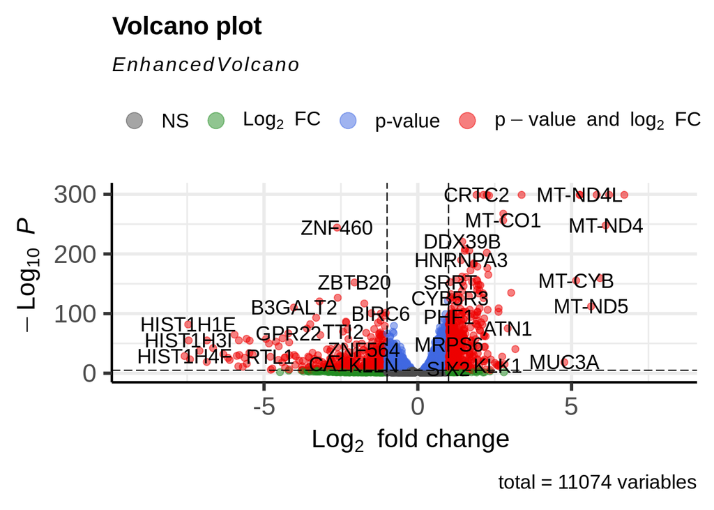

```r
library(EnhancedVolcano)
EnhancedVolcano(res1, lab = rownames(res1), x = 'log2FoldChange', y = 'pvalue')
```

## GSEA

WebGestaltR expects a data frame with two columns, gene name and fold change.

```r
res1$gene <- rownames(res1); rownames(res1) <- NULL
res1 <- subset(res1, select=c("gene","log2FoldChange"))
res1 <- as.data.frame(res1)
nrow(res1)
```

```
## [1] 11074
```

```r
res05 <- subset(res05, res05$padj < 0.05)
res05$gene <- rownames(res05); rownames(res05) <- NULL
res05 <- subset(res05, select=c("gene","log2FoldChange"))
res05 <- as.data.frame(res05)
nrow(res05)
```

```
## [1] 14972
```

### GO Biological process

Our first try at GSEA will use the same reference set we used for overrepresentation analysis in the single-cell data, GO Biological process.

```r
GO_bp <- suppressWarnings(WebGestaltR(enrichMethod = "GSEA",
                          enrichDatabase = "geneontology_Biological_Process_noRedundant",
                          interestGene = res1,
                          interestGeneType = "genesymbol",
                          isOutput = FALSE))
```

```
## Loading the functional categories...
## Loading the ID list...
## Performing the enrichment analysis...
## 1000 permutations of score complete...
```

```r
nrow(GO_bp)
```

```
## [1] 7
```

```r
GO_bp <- GO_bp[order(GO_bp$normalizedEnrichmentScore, decreasing = TRUE),]
subset(GO_bp, select=c("geneSet","description","normalizedEnrichmentScore","pValue","FDR","size"))
```

```
##      geneSet                                               description
## 7 GO:0098742 cell-cell adhesion via plasma-membrane adhesion molecules
## 1 GO:0071824                  protein-DNA complex subunit organization
## 2 GO:0071103                                   DNA conformation change
## 3 GO:0006333                         chromatin assembly or disassembly
## 4 GO:0009593                            detection of chemical stimulus
## 5 GO:0007606                   sensory perception of chemical stimulus
## 6 GO:0050906      detection of stimulus involved in sensory perception
##   normalizedEnrichmentScore pValue         FDR size
## 7                 -2.057136      0 0.004477289  165
## 1                 -2.448386      0 0.000000000  166
## 2                 -2.466140      0 0.000000000  162
## 3                 -2.699728      0 0.000000000  109
## 4                 -3.095128      0 0.000000000   79
## 5                 -3.118737      0 0.000000000   86
## 6                 -3.126586      0 0.000000000   84
```

```r
GO_bp_05 <- suppressWarnings(WebGestaltR(enrichMethod = "GSEA",
                             enrichDatabase = "geneontology_Biological_Process_noRedundant",
                             interestGene = res05,
                             interestGeneType = "genesymbol",
                             isOutput = FALSE))
```

```
## Loading the functional categories...
## Loading the ID list...
## Performing the enrichment analysis...
## 1000 permutations of score complete...
```

```r
nrow(GO_bp_05)
```

```
## [1] 6
```

```r
GO_bp_05 <- GO_bp_05[order(GO_bp_05$normalizedEnrichmentScore, decreasing = TRUE),]
subset(GO_bp_05, select=c("geneSet","description","normalizedEnrichmentScore","pValue","FDR","size"))
```

```
##      geneSet                                          description
## 6 GO:0071824             protein-DNA complex subunit organization
## 5 GO:0071103                              DNA conformation change
## 1 GO:0006333                    chromatin assembly or disassembly
## 2 GO:0050906 detection of stimulus involved in sensory perception
## 3 GO:0007606              sensory perception of chemical stimulus
## 4 GO:0009593                       detection of chemical stimulus
##   normalizedEnrichmentScore pValue         FDR size
## 6                 -1.876542      0 0.006502960  159
## 5                 -1.892780      0 0.006384724  152
## 1                 -2.147279      0 0.000000000  102
## 2                 -2.457005      0 0.000000000   73
## 3                 -2.462597      0 0.000000000   72
## 4                 -2.514569      0 0.000000000   67
```

### GO Cellular Component

Ooh for this one, looking at cell components might actually be useful.

```r
GO_cc <- suppressWarnings(WebGestaltR(enrichMethod = "GSEA",
                             enrichDatabase = "geneontology_Cellular_Component_noRedundant",
                             interestGene = res05,
                             interestGeneType = "genesymbol",
                             isOutput = FALSE))
```

```
## Loading the functional categories...
## Loading the ID list...
## Performing the enrichment analysis...
## 1000 permutations of score complete...
```

```r
nrow(GO_cc)
```

```
## [1] 4
```

```r
GO_cc <- GO_cc[order(GO_cc$normalizedEnrichmentScore, decreasing = TRUE),]
subset(GO_cc, select=c("geneSet","description","normalizedEnrichmentScore","pValue","FDR","size"))
```

[output not shown]

```r
GO_cc_05 <- suppressWarnings(WebGestaltR(enrichMethod = "GSEA",
                             enrichDatabase = "geneontology_Cellular_Component_noRedundant",
                             interestGene = res05,
                             interestGeneType = "genesymbol",
                             isOutput = FALSE))
```

```
## Loading the functional categories...
## Loading the ID list...
## Performing the enrichment analysis...
## 1000 permutations of score complete...
```

```r
nrow(GO_cc_05)
```

```
## [1] 3
```

```r
GO_cc_05 <- GO_cc_05[order(GO_cc_05$normalizedEnrichmentScore, decreasing = TRUE),]
subset(GO_cc_05, select=c("geneSet","description","normalizedEnrichmentScore","pValue","FDR","size"))
```

```
##      geneSet           description normalizedEnrichmentScore      pValue
## 3 GO:0000791           euchromatin                 -1.744466 0.008185539
## 1 GO:0032993   protein-DNA complex                 -2.382457 0.000000000
## 2 GO:0044815 DNA packaging complex                 -2.676798 0.000000000
##          FDR size
## 3 0.02364298   20
## 1 0.00000000  103
## 2 0.00000000   47
```

So there’s more ribosomal-associated transcripts in the poly-A selected cells (that seems correct and encouraging?), whereas the rRNA depleted cells have transcripts with more to do with DNA packaging (i.e. histones).

### Cell types

Let’s try a custom set for cell types, as curated by the folks at http://www.gsea-msigdb.org/

```r
C8 <- suppressWarnings(WebGestaltR(enrichMethod = "GSEA",
                       enrichDatabaseFile = "GSEA_custom_sets/c8.all.v7.5.1.symbols.gmt",
                       enrichDatabaseType = "genesymbol",
                       interestGene = res1,
                       interestGeneType = "genesymbol",
                       isOutput = FALSE))
```

```
## Loading the functional categories...
## Loading the ID list...
## Performing the enrichment analysis...
## 1000 permutations of score complete...
```

```r
nrow(C8)
```

```
## [1] 99
```

```r
C8 <- C8[order(C8$normalizedEnrichmentScore, decreasing = TRUE),]
head(subset(C8, select=c("geneSet","normalizedEnrichmentScore","pValue","FDR","size")))
```

```
##                                                             geneSet
## 5                          GAUTAM_EYE_IRIS_CILIARY_BODY_FIBROBLASTS
## 3 DURANTE_ADULT_OLFACTORY_NEUROEPITHELIUM_FIBROBLASTS_STROMAL_CELLS
## 2                          FAN_OVARY_CL14_MATURE_SMOOTH_MUSCLE_CELL
## 1                               AIZARANI_LIVER_C21_STELLATE_CELLS_1
## 4                       BUSSLINGER_ESOPHAGEAL_LATE_SUPRABASAL_CELLS
## 6                        RUBENSTEIN_SKELETAL_MUSCLE_SATELLITE_CELLS
##   normalizedEnrichmentScore pValue          FDR size
## 5                  2.323472      0 0.0023322761   70
## 3                  2.322926      0 0.0011661381   61
## 2                  2.302358      0 0.0007774254  241
## 1                  2.300463      0 0.0005830690  147
## 4                  2.231167      0 0.0013993657   88
## 6                  2.191843      0 0.0023322761  254
```

Note that this one only has cell type pathways upregulated in the polyA, no cell types that are more upregulated in the ribo-depleted.

```r
C8_05 <- suppressWarnings(WebGestaltR(enrichMethod = "GSEA",
                       enrichDatabaseFile = "GSEA_custom_sets/c8.all.v7.5.1.symbols.gmt",
                       enrichDatabaseType = "genesymbol",
                       interestGene = res05,
                       interestGeneType = "genesymbol",
                       isOutput = FALSE))
```

```
## Loading the functional categories...
## Loading the ID list...
## Performing the enrichment analysis...
## 1000 permutations of score complete...
```

```r
nrow(C8_05)
```

```
## [1] 84
```

```r
C8_05 <- C8_05[order(C8_05$normalizedEnrichmentScore, decreasing = TRUE),]
head(subset(C8_05, select=c("geneSet","normalizedEnrichmentScore","pValue","FDR","size")))
```

```
##                                                             geneSet
## 1                          FAN_OVARY_CL14_MATURE_SMOOTH_MUSCLE_CELL
## 2 DURANTE_ADULT_OLFACTORY_NEUROEPITHELIUM_FIBROBLASTS_STROMAL_CELLS
## 3                          GAUTAM_EYE_IRIS_CILIARY_BODY_FIBROBLASTS
## 7                          LAKE_ADULT_KIDNEY_C8_DECENDING_THIN_LIMB
## 5              FAN_OVARY_CL10_PUTATIVE_EARLY_ATRESIA_GRANULOSA_CELL
## 4                    RUBENSTEIN_SKELETAL_MUSCLE_SMOOTH_MUSCLE_CELLS
##   normalizedEnrichmentScore pValue         FDR size
## 1                  2.525240      0 0.000000000  231
## 2                  2.505438      0 0.000000000   59
## 3                  2.441404      0 0.000000000   68
## 7                  2.372145      0 0.001484616  226
## 5                  2.364002      0 0.001187693  204
## 4                  2.342506      0 0.000989744  327
```

Same here, a lot of smooth muscle cells and fibroblast-looking things. Not sure how confident I am in this gene set though.

## Conclusions

The genes that are most upregulated in the rRNA depletion are the genes encoding histones and “RNAs with jobs”, like telomerase RNA and endoribonucleases. I’m not totally sure why, my quick literature review seems to indicate they should still be polyadenylated, but perhaps not.

The genes that are most upregulated in the poly-A capture are mitochondrial genes (still need to look into why that is), and ribosomal-associated genes (not surprising).